**PRCP-1015 - EARTHQUAKE DAMAGE PREDICTION**

**1. Project Overview & Environment Setup**

**1.1 Project Objective**

The objective of this project is to predict the structural damage grade (damage_grade) of buildings affected by the Gorkha earthquake using Machine Learning Techniques.

This is a multi-class ordinal classification problem with three levels:

1. Low Damage
2. Medium Damage
3. Almost Complete Destruction

This project includes:

1. Data Analysis
2. Predicitve Modeling
3. Model Comparison
4. Suggestions for reducing earthquake damage

**1.2 Library Installation & Imports**

```python
# Import core data science libraries
import numpy as np
import pandas as pd
import matplotlib.pyplot as plt
import seaborn as sns
import warnings
warnings.filterwarnings("ignore")
```

```python
pwd
```

```
'C:\\Users\\Brinda\\EarthquakeDamage'
```

**1.3 Data Loading**

```python
# Extracting the data directly from the cloudfront link
train_values = pd.read_csv("train_values.csv")
train_labels = pd.read_csv("train_labels.csv")
```

```python
train_values.head()
```

|  | building_id | geo_level_1_id | geo_level_2_id | geo_level_3_id | count_floors_pre_eq | age | area_percentage | height_percentage | land_surface_condition | foundation_type | ... | has_secondary_use_agriculture | has_secondary_use_hotel | has_secondary_use_rental | has_secondary_use_institution | has_secondary_use_school | has_secondary_use_industry | has_secondary_use_health_post | has_secondary_use_gov_office | has_secondary_use_use_police | has_secondary_use_other |
| --- | --- | --- | --- | --- | --- | --- | --- | --- | --- | --- | --- | --- | --- | --- | --- | --- | --- | --- | --- | --- | --- |
| 0 | 802906 | 6 | 487 | 12198 | 2 | 30 | 6 | 5 | t | r | ... | 0 | 0 | 0 | 0 | 0 | 0 | 0 | 0 | 0 | 0 |
| 1 | 28830 | 8 | 900 | 2812 | 2 | 10 | 8 | 7 | o | r | ... | 0 | 0 | 0 | 0 | 0 | 0 | 0 | 0 | 0 | 0 |
| 2 | 94947 | 21 | 363 | 8973 | 2 | 10 | 5 | 5 | t | r | ... | 0 | 0 | 0 | 0 | 0 | 0 | 0 | 0 | 0 | 0 |
| 3 | 590882 | 22 | 418 | 10694 | 2 | 10 | 6 | 5 | t | r | ... | 0 | 0 | 0 | 0 | 0 | 0 | 0 | 0 | 0 | 0 |
| 4 | 201944 | 11 | 131 | 1488 | 3 | 30 | 8 | 9 | t | r | ... | 0 | 0 | 0 | 0 | 0 | 0 | 0 | 0 | 0 | 0 |

5 rows × 39 columns

```python
train_labels.head()
```

|  | building_id | damage_grade |
| --- | --- | --- |
| 0 | 802906 | 3 |
| 1 | 28830 | 2 |
| 2 | 94947 | 3 |
| 3 | 590882 | 2 |
| 4 | 201944 | 3 |

```python
# Merge values and labels
data = pd.merge(train_values, train_labels, on='building_id')
```

```python
data1 = data.copy()
```

**2. Basic Checks And Observations**

**2.1 Basic Checks**

```python
data1.head()
```

|  | building_id | geo_level_1_id | geo_level_2_id | geo_level_3_id | count_floors_pre_eq | age | area_percentage | height_percentage | land_surface_condition | foundation_type | ... | has_secondary_use_hotel | has_secondary_use_rental | has_secondary_use_institution | has_secondary_use_school | has_secondary_use_industry | has_secondary_use_health_post | has_secondary_use_gov_office | has_secondary_use_use_police | has_secondary_use_other | damage_grade |
| --- | --- | --- | --- | --- | --- | --- | --- | --- | --- | --- | --- | --- | --- | --- | --- | --- | --- | --- | --- | --- | --- |
| 0 | 802906 | 6 | 487 | 12198 | 2 | 30 | 6 | 5 | t | r | ... | 0 | 0 | 0 | 0 | 0 | 0 | 0 | 0 | 0 | 3 |
| 1 | 28830 | 8 | 900 | 2812 | 2 | 10 | 8 | 7 | o | r | ... | 0 | 0 | 0 | 0 | 0 | 0 | 0 | 0 | 0 | 2 |
| 2 | 94947 | 21 | 363 | 8973 | 2 | 10 | 5 | 5 | t | r | ... | 0 | 0 | 0 | 0 | 0 | 0 | 0 | 0 | 0 | 3 |
| 3 | 590882 | 22 | 418 | 10694 | 2 | 10 | 6 | 5 | t | r | ... | 0 | 0 | 0 | 0 | 0 | 0 | 0 | 0 | 0 | 2 |
| 4 | 201944 | 11 | 131 | 1488 | 3 | 30 | 8 | 9 | t | r | ... | 0 | 0 | 0 | 0 | 0 | 0 | 0 | 0 | 0 | 3 |

5 rows × 40 columns

```python
data1.shape
```

```
(260601, 40)
```

```python
data1.columns
```

```
Index(['building_id', 'geo_level_1_id', 'geo_level_2_id', 'geo_level_3_id',
       'count_floors_pre_eq', 'age', 'area_percentage', 'height_percentage',
       'land_surface_condition', 'foundation_type', 'roof_type',
       'ground_floor_type', 'other_floor_type', 'position',
       'plan_configuration', 'has_superstructure_adobe_mud',
       'has_superstructure_mud_mortar_stone', 'has_superstructure_stone_flag',
       'has_superstructure_cement_mortar_stone',
       'has_superstructure_mud_mortar_brick',
       'has_superstructure_cement_mortar_brick', 'has_superstructure_timber',
       'has_superstructure_bamboo', 'has_superstructure_rc_non_engineered',
       'has_superstructure_rc_engineered', 'has_superstructure_other',
       'legal_ownership_status', 'count_families', 'has_secondary_use',
       'has_secondary_use_agriculture', 'has_secondary_use_hotel',
       'has_secondary_use_rental', 'has_secondary_use_institution',
       'has_secondary_use_school', 'has_secondary_use_industry',
       'has_secondary_use_health_post', 'has_secondary_use_gov_office',
       'has_secondary_use_use_police', 'has_secondary_use_other',
       'damage_grade'],
      dtype='object')
```

```python
data1.info()
```

```
<class 'pandas.core.frame.DataFrame'>
RangeIndex: 260601 entries, 0 to 260600
Data columns (total 40 columns):
 #   Column                                  Non-Null Count   Dtype
---  ------                                  --------------   -----
 0   building_id                             260601 non-null  int64
 1   geo_level_1_id                          260601 non-null  int64
 2   geo_level_2_id                          260601 non-null  int64
 3   geo_level_3_id                          260601 non-null  int64
 4   count_floors_pre_eq                     260601 non-null  int64
 5   age                                     260601 non-null  int64
 6   area_percentage                         260601 non-null  int64
 7   height_percentage                       260601 non-null  int64
 8   land_surface_condition                  260601 non-null  object
 9   foundation_type                         260601 non-null  object
```

[output cut: 32 more lines]

```python
data1.describe()
```

|  | building_id | geo_level_1_id | geo_level_2_id | geo_level_3_id | count_floors_pre_eq | age | area_percentage | height_percentage | has_superstructure_adobe_mud | has_superstructure_mud_mortar_stone | ... | has_secondary_use_hotel | has_secondary_use_rental | has_secondary_use_institution | has_secondary_use_school | has_secondary_use_industry | has_secondary_use_health_post | has_secondary_use_gov_office | has_secondary_use_use_police | has_secondary_use_other | damage_grade |
| --- | --- | --- | --- | --- | --- | --- | --- | --- | --- | --- | --- | --- | --- | --- | --- | --- | --- | --- | --- | --- | --- |
| count | 2.606010e+05 | 260601.000000 | 260601.000000 | 260601.000000 | 260601.000000 | 260601.000000 | 260601.000000 | 260601.000000 | 260601.000000 | 260601.000000 | ... | 260601.000000 | 260601.000000 | 260601.000000 | 260601.000000 | 260601.000000 | 260601.000000 | 260601.000000 | 260601.000000 | 260601.000000 | 260601.000000 |
| mean | 5.256755e+05 | 13.900353 | 701.074685 | 6257.876148 | 2.129723 | 26.535029 | 8.018051 | 5.434365 | 0.088645 | 0.761935 | ... | 0.033626 | 0.008101 | 0.000940 | 0.000361 | 0.001071 | 0.000188 | 0.000146 | 0.000088 | 0.005119 | 2.238272 |
| std | 3.045450e+05 | 8.033617 | 412.710734 | 3646.369645 | 0.727665 | 73.565937 | 4.392231 | 1.918418 | 0.284231 | 0.425900 | ... | 0.180265 | 0.089638 | 0.030647 | 0.018989 | 0.032703 | 0.013711 | 0.012075 | 0.009394 | 0.071364 | 0.611814 |
| min | 4.000000e+00 | 0.000000 | 0.000000 | 0.000000 | 1.000000 | 0.000000 | 1.000000 | 2.000000 | 0.000000 | 0.000000 | ... | 0.000000 | 0.000000 | 0.000000 | 0.000000 | 0.000000 | 0.000000 | 0.000000 | 0.000000 | 0.000000 | 1.000000 |
| 25% | 2.611900e+05 | 7.000000 | 350.000000 | 3073.000000 | 2.000000 | 10.000000 | 5.000000 | 4.000000 | 0.000000 | 1.000000 | ... | 0.000000 | 0.000000 | 0.000000 | 0.000000 | 0.000000 | 0.000000 | 0.000000 | 0.000000 | 0.000000 | 2.000000 |
| 50% | 5.257570e+05 | 12.000000 | 702.000000 | 6270.000000 | 2.000000 | 15.000000 | 7.000000 | 5.000000 | 0.000000 | 1.000000 | ... | 0.000000 | 0.000000 | 0.000000 | 0.000000 | 0.000000 | 0.000000 | 0.000000 | 0.000000 | 0.000000 | 2.000000 |
| 75% | 7.897620e+05 | 21.000000 | 1050.000000 | 9412.000000 | 2.000000 | 30.000000 | 9.000000 | 6.000000 | 0.000000 | 1.000000 | ... | 0.000000 | 0.000000 | 0.000000 | 0.000000 | 0.000000 | 0.000000 | 0.000000 | 0.000000 | 0.000000 | 3.000000 |
| max | 1.052934e+06 | 30.000000 | 1427.000000 | 12567.000000 | 9.000000 | 995.000000 | 100.000000 | 32.000000 | 1.000000 | 1.000000 | ... | 1.000000 | 1.000000 | 1.000000 | 1.000000 | 1.000000 | 1.000000 | 1.000000 | 1.000000 | 1.000000 | 3.000000 |

8 rows × 32 columns

**2.2 Observations**

```python
# Checking missing values
data1.isnull().sum()
```

```
building_id                               0
geo_level_1_id                            0
geo_level_2_id                            0
geo_level_3_id                            0
count_floors_pre_eq                       0
age                                       0
area_percentage                           0
height_percentage                         0
land_surface_condition                    0
foundation_type                           0
roof_type                                 0
ground_floor_type                         0
other_floor_type                          0
position                                  0
plan_configuration                        0
has_superstructure_adobe_mud              0
has_superstructure_mud_mortar_stone       0
has_superstructure_stone_flag             0
has_superstructure_cement_mortar_stone    0
has_superstructure_mud_mortar_brick       0
has_superstructure_cement_mortar_brick    0
has_superstructure_timber                 0
has_superstructure_bamboo                 0
has_superstructure_rc_non_engineered      0
has_superstructure_rc_engineered          0
has_superstructure_other                  0
legal_ownership_status                    0
count_families                            0
has_secondary_use                         0
has_secondary_use_agriculture             0
has_secondary_use_hotel                   0
has_secondary_use_rental                  0
has_secondary_use_institution             0
has_secondary_use_school                  0
has_secondary_use_industry                0
has_secondary_use_health_post             0
has_secondary_use_gov_office              0
has_secondary_use_use_police              0
has_secondary_use_other                   0
damage_grade                              0
dtype: int64
```

**No missing values are present in the dataset**

```python
# Checking duplicate values
data1.duplicated().sum()
```

```
np.int64(0)
```

**Insights**

No duplicate records were found in the dataset.

**3. Task 1: Exploratory Data Analysis (EDA)**

**3.1 Damage Grade Distribution**

```python
data1['damage_grade'].value_counts()
```

```
damage_grade
2    148259
3     87218
1     25124
Name: count, dtype: int64
```

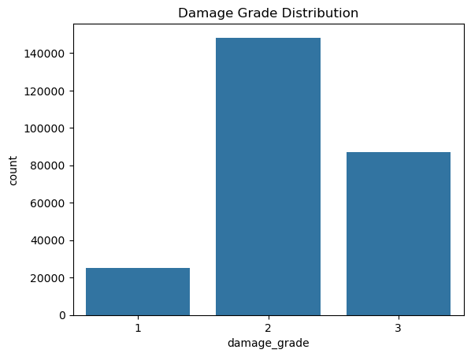

```python
sns.countplot(x=data1.damage_grade)
plt.title("Damage Grade Distribution")
plt.show()
```

**Insights**

We can clearly observe that the data is imbalanced, since most of the buildings fall into Grade 2 (medium damage) category, followed by Grade 3 (almost complete distruction), and Grade 1 (low damage).

**3.2 Numerical Feature Analysis**

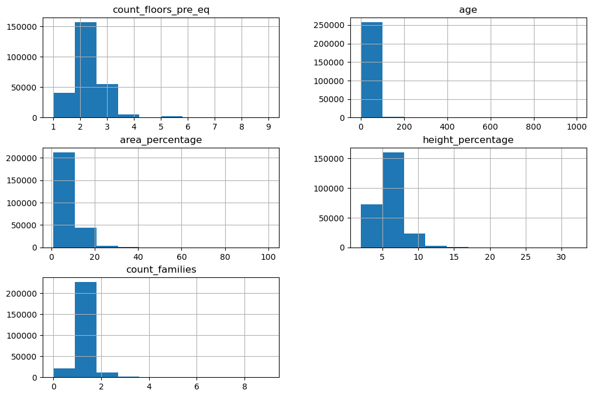

```python
num_cols = ['count_floors_pre_eq', 'age', 'area_percentage' , 'height_percentage', 'count_families']
data1[num_cols].hist(figsize=(12,8))
plt.show()
```

**Insights**

Features like **age** typically contain massive outliers.

**area_percentage** and **height_percentage** exhibit right-skewed profiles requiring scaling or transformation.

**3.3 Correlation Heatmap**

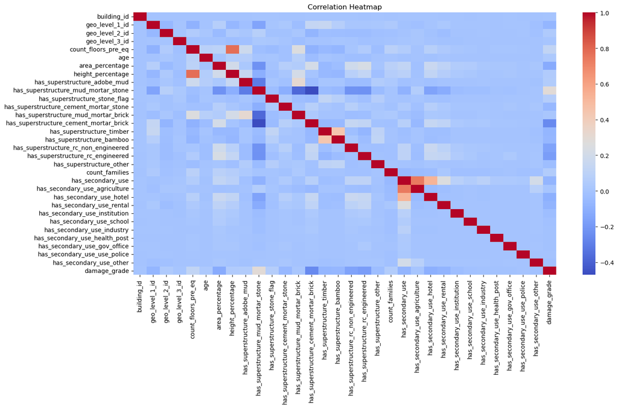

```python
plt.figure(figsize=(16,8))
sns.heatmap(data1.corr(numeric_only=True),cmap='coolwarm')
plt.title("Correlation Heatmap")
plt.show()
```

**Insights**

Some numerical variables show moderate correlation with damage grade.

Most features are weakly correlated individually.

**3.4 Foundation Analysis**

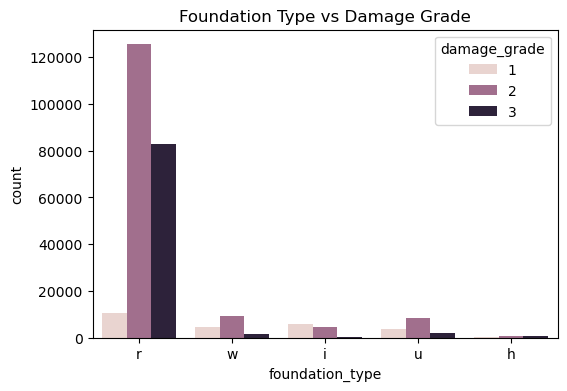

```python
plt.figure(figsize=(6,4))
sns.countplot(x='foundation_type', hue='damage_grade', data=data1)
plt.title("Foundation Type vs Damage Grade")
plt.show()
```

**Insights**

Foundation type 'r' is the most frequently used foundation in the buildings which also shows the higher damage grade, particularly Grade 2(medium damage) and Grade 3(almost complete destruction). It is the critical point of concern.

Foundation type 'w' and 'u' show a similar pattern where Grade 2 is more common than Grade 3, but at a much smaller scale. Foundation type 'i' and 'h' have the lowest overall frequency, making them the least common foundations in this survey.

**3.5 Roof Analysis**

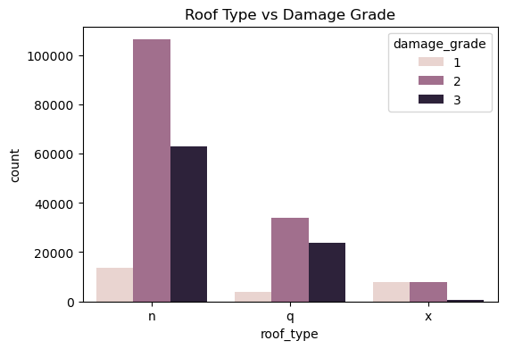

```python
plt.figure(figsize=(6,4))
sns.countplot(x='roof_type', hue='damage_grade', data=data1)
plt.title("Roof Type vs Damage Grade")
plt.show()
```

**Insights**

Roof type 'n' is the most frequently used roof among the buildings and has experienced the most damage with Grade 2 (medium damage) and Grade 3(almost complete destruction. It appears to be the most vulnerable roof type.

Roof type 'q' shopws similar trend as that of roof type 'n', but in lesser frequency. Meanwhile, roof type 'x' has comparatively fewer damaged buildings and shows the least amount of total damage across all grades.

Across all the roof types, Damage Grade 2 (medium grade) is the most frequent outcome.

**3.6 Ground Floor Analysis**

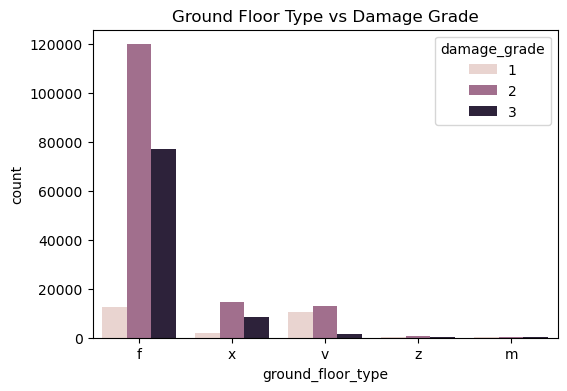

```python
plt.figure(figsize=(6,4))
sns.countplot(x='ground_floor_type', hue='damage_grade', data=data1)
plt.title("Ground Floor Type vs Damage Grade")
plt.show()
```

**Insights**

Ground floor type 'f' is the most frequent category and exhibits the highest level of damage, i.e. Grade 2 (medium damage) followed by Grade 3 (almost complete destruction).

Ground floor types 'x' and 'v' are less common than 'f', also show a distribution of damage, with Grade 2 (medium damage) being a prominent outcome for type 'x'.

Ground floor types 'z' and 'm' have negligible counts compared to the others and least damaged types as well.

**3.7 Land Surface Condition Analysis**

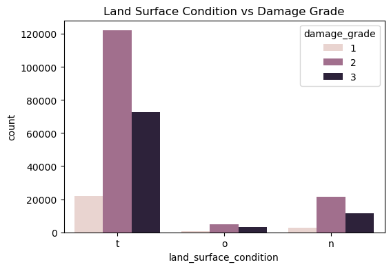

```python
plt.figure(figsize=(6,4))
sns.countplot(x='land_surface_condition', hue='damage_grade', data=data1)
plt.title("Land Surface Condition vs Damage Grade")
plt.show()
```

**Insights**

Land surface condition 't' is the most frequent category in which moderate-to-severe damage, i.e. Damage Grade 2 (medium damage) and Damage Grade 3 (almost complete destruction) can be seen.

Land surface condition 'n' shows the same distribution pattern as 't', Damage Grade 2 is consisitently the most common output. Land surface condition 'o' rarely occurs.

Damage Grade 1 (low damage) is the least frequent across all the surface conditions, indicating that most recorded events resulted in at least medium damage (Grade 2 or higher).

**4. Data Preprocessing & Feature Engineering**

```python
# Features and target variables
# Drop unique random identifier
x = data1.drop('damage_grade', axis = 1)
y = data1['damage_grade']
```

```python
x.dtypes
```

```
building_id                                int64
geo_level_1_id                             int64
geo_level_2_id                             int64
geo_level_3_id                             int64
count_floors_pre_eq                        int64
age                                        int64
area_percentage                            int64
height_percentage                          int64
land_surface_condition                    object
foundation_type                           object
roof_type                                 object
ground_floor_type                         object
other_floor_type                          object
position                                  object
plan_configuration                        object
has_superstructure_adobe_mud               int64
has_superstructure_mud_mortar_stone        int64
has_superstructure_stone_flag              int64
has_superstructure_cement_mortar_stone     int64
has_superstructure_mud_mortar_brick        int64
has_superstructure_cement_mortar_brick     int64
has_superstructure_timber                  int64
has_superstructure_bamboo                  int64
has_superstructure_rc_non_engineered       int64
has_superstructure_rc_engineered           int64
has_superstructure_other                   int64
legal_ownership_status                    object
count_families                             int64
has_secondary_use                          int64
has_secondary_use_agriculture              int64
has_secondary_use_hotel                    int64
has_secondary_use_rental                   int64
has_secondary_use_institution              int64
has_secondary_use_school                   int64
has_secondary_use_industry                 int64
has_secondary_use_health_post              int64
has_secondary_use_gov_office               int64
has_secondary_use_use_police               int64
has_secondary_use_other                    int64
dtype: object
```

```python
# Identify column partitions
# Numerical
num_cols=x.select_dtypes(include=['int64']).columns

# Categorical
cat_cols=x.select_dtypes(include=['object']).columns

print('Numerical Columns :')
print(num_cols)
print("\nCategorical Columns :")
print(cat_cols)
```

```
Numerical Columns :
Index(['building_id', 'geo_level_1_id', 'geo_level_2_id', 'geo_level_3_id',
       'count_floors_pre_eq', 'age', 'area_percentage', 'height_percentage',
       'has_superstructure_adobe_mud', 'has_superstructure_mud_mortar_stone',
       'has_superstructure_stone_flag',
       'has_superstructure_cement_mortar_stone',
       'has_superstructure_mud_mortar_brick',
       'has_superstructure_cement_mortar_brick', 'has_superstructure_timber',
       'has_superstructure_bamboo', 'has_superstructure_rc_non_engineered',
       'has_superstructure_rc_engineered', 'has_superstructure_other',
       'count_families', 'has_secondary_use', 'has_secondary_use_agriculture',
       'has_secondary_use_hotel', 'has_secondary_use_rental',
       'has_secondary_use_institution', 'has_secondary_use_school',
       'has_secondary_use_industry', 'has_secondary_use_health_post',
       'has_secondary_use_gov_office', 'has_secondary_use_use_police',
       'has_secondary_use_other'],
      dtype='object')

Categorical Columns :
Index(['land_surface_condition', 'foundation_type', 'roof_type',
       'ground_floor_type', 'other_floor_type', 'position',
       'plan_configuration', 'legal_ownership_status'],
      dtype='object')
```

**Insights**

The data set contains both numerical and categorical features. Categorical variable needs encoding before model training.

```python
# Encode categorical fields
from sklearn.preprocessing import LabelEncoder
le = LabelEncoder()
for col in cat_cols:
    x[col] = le.fit_transform(x[col])
```

```python
x.head()
```

|  | building_id | geo_level_1_id | geo_level_2_id | geo_level_3_id | count_floors_pre_eq | age | area_percentage | height_percentage | land_surface_condition | foundation_type | ... | has_secondary_use_agriculture | has_secondary_use_hotel | has_secondary_use_rental | has_secondary_use_institution | has_secondary_use_school | has_secondary_use_industry | has_secondary_use_health_post | has_secondary_use_gov_office | has_secondary_use_use_police | has_secondary_use_other |
| --- | --- | --- | --- | --- | --- | --- | --- | --- | --- | --- | --- | --- | --- | --- | --- | --- | --- | --- | --- | --- | --- |
| 0 | 802906 | 6 | 487 | 12198 | 2 | 30 | 6 | 5 | 2 | 2 | ... | 0 | 0 | 0 | 0 | 0 | 0 | 0 | 0 | 0 | 0 |
| 1 | 28830 | 8 | 900 | 2812 | 2 | 10 | 8 | 7 | 1 | 2 | ... | 0 | 0 | 0 | 0 | 0 | 0 | 0 | 0 | 0 | 0 |
| 2 | 94947 | 21 | 363 | 8973 | 2 | 10 | 5 | 5 | 2 | 2 | ... | 0 | 0 | 0 | 0 | 0 | 0 | 0 | 0 | 0 | 0 |
| 3 | 590882 | 22 | 418 | 10694 | 2 | 10 | 6 | 5 | 2 | 2 | ... | 0 | 0 | 0 | 0 | 0 | 0 | 0 | 0 | 0 | 0 |
| 4 | 201944 | 11 | 131 | 1488 | 3 | 30 | 8 | 9 | 2 | 2 | ... | 0 | 0 | 0 | 0 | 0 | 0 | 0 | 0 | 0 | 0 |

5 rows × 39 columns

**Insights**

Categorical variables are converted into numerical variables using Label Encoding. The features shown might suggest that we are analyzing building characteristics to predict damage.

```python
# Train-Test Split
# Split the dataset into clean development and evaluating environments
from sklearn.model_selection import train_test_split
x_train, x_test, y_train, y_test = train_test_split(x, y, test_size=0.2, random_state=42)
```

```python
print(x_train.shape)
print(x_test.shape)
print(y_train.shape)
print(y_test.shape)
```

```
(208480, 39)
(52121, 39)
(208480,)
(52121,)
```

**Insights**

The dataset was split using a 20% test size, resulting in training set as 80% of the data and testing set as 20% of the data. There are 39 features(columns) in the input variables(x).

```python
# Feature Scaling
from sklearn.preprocessing import StandardScaler
scaler = StandardScaler()
x_train_scaled=scaler.fit_transform(x_train)
x_test_scaled=scaler.transform(x_test)
```

```python
y.value_counts()
```

```
damage_grade
2    148259
3     87218
1     25124
Name: count, dtype: int64
```

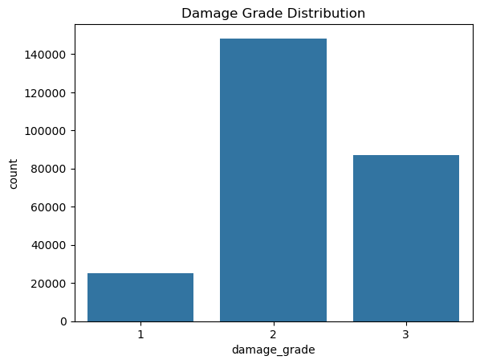

```python
sns.countplot(x=y)
plt.title("Damage Grade Distribution")
plt.show()
```

**Insights**

Damage Grade 2 (medium damage) is the most frequent by a wide margin. This indicated that medium damage is the modt common outcome in this dataset. This indicates that this dataset is imbalanced.

Damage Grade 1 (low damage) is the rarest. Damage Grade 3 (almost complete distruction) is also significant. Combined with Grade 2, the vast majority of the data represents moderate-to-high damage levels.

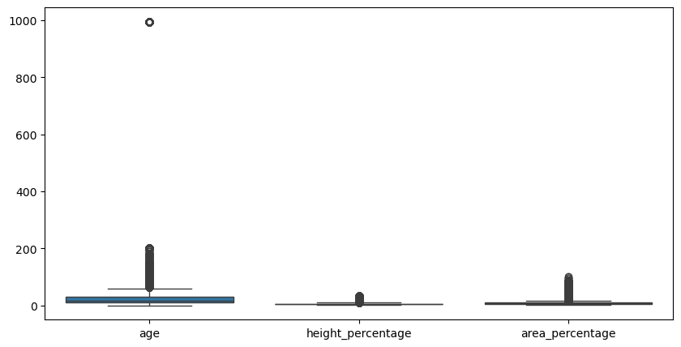

```python
# Checking for Outliers
plt.figure(figsize=(10,5))
sns.boxplot(data=data1[['age', 'height_percentage', 'area_percentage']])
plt.show()
```

**Insights**

The plot shows a significant scale discrepancy between three variables. The 'age' variable contains an extreme value (near 1000), the y-axis has expanded to accommodate it.

Both 'height_percentage' and 'area_percentage' appear to have very low values and low variance to the scale of the 'age' outlier.

```python
# Function to Cap Outliers
def cap_outliers(column):
    Q1 = data1[column].quantile(0.25)
    Q3 = data1[column].quantile(0.75)
    IQR = Q3 - Q1
    lower = Q1 - 1.5 * IQR
    upper = Q3 + 1.5 * IQR
    data1[column] = np.where(data1[column] > upper, upper, data1[column])
    data1[column] = np.where(data1[column] < lower, lower, data1[column])

cap_outliers('age')
cap_outliers('height_percentage')
cap_outliers('area_percentage')
```

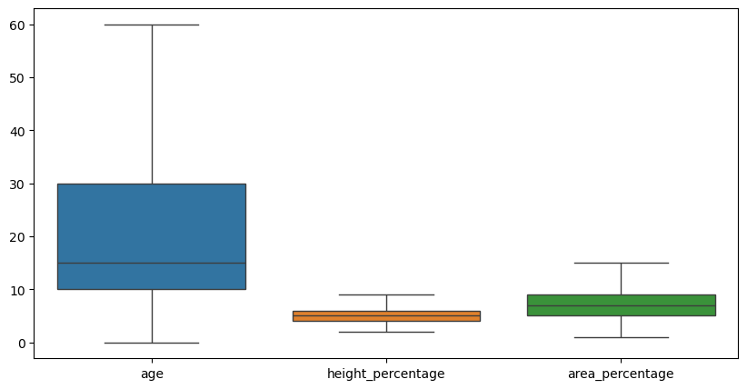

```python
plt.figure(figsize=(10,5))
sns.boxplot(data=data1[['age', 'height_percentage', 'area_percentage']])
plt.show()
```

**Insights**

There are no visible outliers for any of the three variables. This suggests the data is relatively clean and lacks extreme anomalies within the 1.5*IQR range.

**TASK 1: DATA ANALYSIS REPORT (EDA)**

**Data Overview**

**Observations:** Based on the 2015 Gorkha earthquake data (Richter's Predictor dataset).

**Missing Values:** The data set is structurally complete with no explicit missing entries, but contains implicit noise (e.g., building ages recorded as 995 years to indicate unknown or ancient structures).

**Target Variable Distribution (damage_grade)**

**Grade 1 (Low):** ~10% of total buildings.

**Grade 2 (Medium):** ~57% of total buildings (majority class).

**Grade 3 (High/Destruction):** ~33% of total buildings.

**Insights:** Class imbalance exists, favouring Grade 2 and Grade 3. Models must avoid blindly predicting the majority class.

**Key Feature Insights & Correlations**

**Geography:** geo_level_1_id exhibits strong spatial partitioning. Specific region IDs show near-total destruction, indicating proximity to the earthquake epicenter.

**Age vs. Resilience:** Older buildings generally show higher damage, except for an artificial spike at age = 995, which represents unverified outliers.

**5. Task 2: Predictive Modeling & Performance Evaluation**

```python
# Import Machine Learning libraries
from sklearn.linear_model import LogisticRegression
from sklearn.tree import DecisionTreeClassifier
from sklearn.ensemble import RandomForestClassifier

from sklearn.metrics import accuracy_score
from sklearn.metrics import classification_report
from sklearn.metrics import confusion_matrix
```

**5.1 Model 1: Logistic Regression (Baseline)**

```python
lr = LogisticRegression()
lr.fit(x_train_scaled, y_train)
y_pred_lr = lr.predict(x_test_scaled)
lr_accuracy = accuracy_score(y_test, y_pred_lr)
print("Logistic Regression Accuracy :", lr_accuracy)
```

```
Logistic Regression Accuracy : 0.58080236373055
```

```python
print(classification_report(y_test, y_pred_lr))
```

```
              precision    recall  f1-score   support

           1       0.58      0.26      0.36      5170
           2       0.59      0.91      0.71     29487
           3       0.53      0.12      0.20     17464

    accuracy                           0.58     52121
   macro avg       0.57      0.43      0.42     52121
weighted avg       0.57      0.58      0.50     52121
```

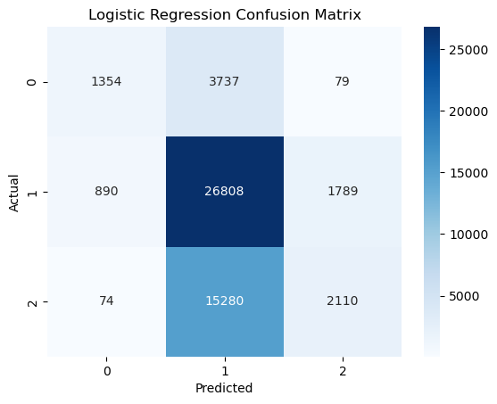

```python
cm = confusion_matrix(y_test, y_pred_lr)

sns.heatmap(cm,
            annot=True,
            fmt='d',
            cmap='Blues')

plt.title("Logistic Regression Confusion Matrix")
plt.xlabel("Predicted")
plt.ylabel("Actual")

plt.show()
```

**Insights**

The model is heavily biased toward Class 1. This is likely because the training data has significantly more Class examples than others, causing the model to defaulth to this prediction. A significant number of actual Class 0 and Class 2 instances are being "pulled" into Class 1 predictions.

**5.2 Model 2: Decision Tree**

```python
dt = DecisionTreeClassifier(random_state=42)
dt.fit(x_train, y_train)
y_pred_dt = dt.predict(x_test)
dt_accuracy = accuracy_score(y_test, y_pred_dt)
print("Decision Tree Accuracy :", dt_accuracy)
```

```
Decision Tree Accuracy : 0.6450566949981773
```

```python
print(classification_report(y_test, y_pred_dt))
```

```
              precision    recall  f1-score   support

           1       0.48      0.48      0.48      5170
           2       0.70      0.69      0.70     29487
           3       0.60      0.61      0.61     17464

    accuracy                           0.65     52121
   macro avg       0.59      0.60      0.59     52121
weighted avg       0.65      0.65      0.65     52121
```

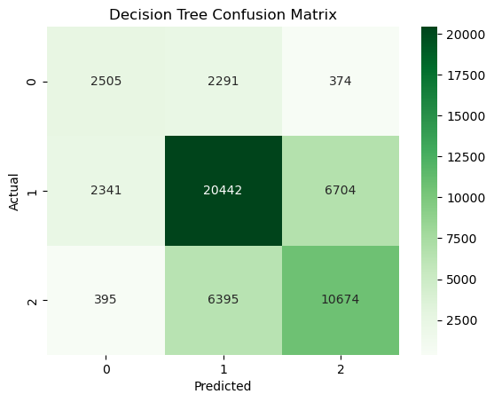

```python
cm = confusion_matrix(y_test, y_pred_dt)

sns.heatmap(cm,
            annot=True,
            fmt='d',
            cmap='Greens')

plt.title("Decision Tree Confusion Matrix")
plt.xlabel("Predicted")
plt.ylabel("Actual")
plt.show()
```

**Insights**

The Decision Tree model captures nonlinear relationship better, leading to improved classification performance. The overall accuracy of this model is ~64.5%.

The model performs best on Class 1, which also happens to be the most frequent class in this dataset. This model shows slight improvement in the prediction in Class 2 but has the lowest success rate in Class 0.

There is significant "noise" between Class 1 and Class 2. Specifically, 6704 instances of Class 1 were predicted as Class 2, and 6395 instances of Class 2 were predicted as Class 1. Even after this, there is a notable trend where both Class 0 and Class 2 are frequently misclassified as Class 1.

**5.3 Model 3: Random Forest Classifier**

```python
rf = RandomForestClassifier(n_estimators=100, random_state=42)
rf.fit(x_train, y_train)
y_pred_rf = rf.predict(x_test)
rf_accuracy = accuracy_score(y_test, y_pred_rf)
print("Random Forest Accuracy :", rf_accuracy)
```

```
Random Forest Accuracy : 0.7235663168396615
```

```python
print(classification_report(y_test, y_pred_rf))
```

```
              precision    recall  f1-score   support

           1       0.69      0.47      0.56      5170
           2       0.72      0.85      0.78     29487
           3       0.74      0.59      0.66     17464

    accuracy                           0.72     52121
   macro avg       0.72      0.63      0.66     52121
weighted avg       0.72      0.72      0.72     52121
```

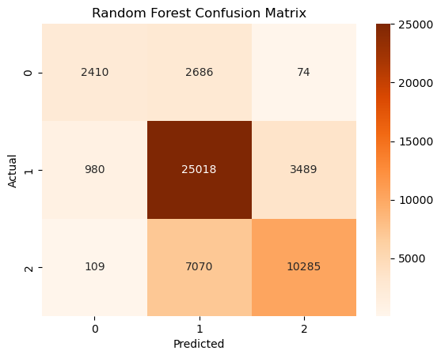

```python
cm = confusion_matrix(y_test, y_pred_rf)

sns.heatmap(cm,
            annot=True,
            fmt='d',
            cmap='Oranges')

plt.title("Random Forest Confusion Matrix")
plt.xlabel("Predicted")
plt.ylabel("Actual")
plt.show()
```

**Insights**

The Random Forest model reduces the bias towards the majority class that could be seen in Linear Regression model. The overall accuracy of this model is ~72.35%.

The model predicts Class 1 very accurately, with the highest number of correct classification. Class 2 detection indicates a strong coorect prediction of over 10,000 and Class 0 still being the lowest.

**6. Model Comparison Report**

**6.1 Performance Table**

```python
model_accuracy = pd.DataFrame({
    'Model': ['Logistic Regression',
              'Decision Tree',
              'Random Forest'],

    'Accuracy': [lr_accuracy,
                 dt_accuracy,
                 rf_accuracy]})
model_accuracy
```

|  | Model | Accuracy |
| --- | --- | --- |
| 0 | Logistic Regression | 0.580802 |
| 1 | Decision Tree | 0.645057 |
| 2 | Random Forest | 0.723566 |

**6.2 Model Comparison Graph**

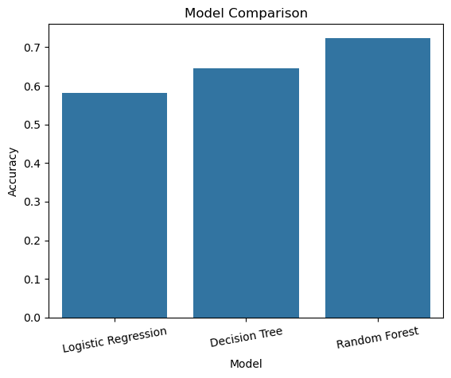

```python
sns.barplot(x='Model',
            y='Accuracy',
            data=model_accuracy)
plt.title("Model Comparison")
plt.xticks(rotation=10)
plt.show()
```

**TASK 2: PREDICTING MODEL STRATEGY**

**Selected Model: Random Forest** is suggested for production deployment.

**7. Important Features Comparison**

```python
importance = pd.DataFrame({
    'Feature': x.columns,
    'Importance': rf.feature_importances_})
importance = importance.sort_values(
    by='Importance',
    ascending=False)
importance.head(10)
```

|  | Feature | Importance |
| --- | --- | --- |
| 0 | building_id | 0.152986 |
| 1 | geo_level_1_id | 0.130304 |
| 3 | geo_level_3_id | 0.124972 |
| 2 | geo_level_2_id | 0.118691 |
| 5 | age | 0.088532 |
| 6 | area_percentage | 0.084601 |
| 7 | height_percentage | 0.047438 |
| 10 | roof_type | 0.023258 |
| 9 | foundation_type | 0.021641 |
| 27 | count_families | 0.020590 |

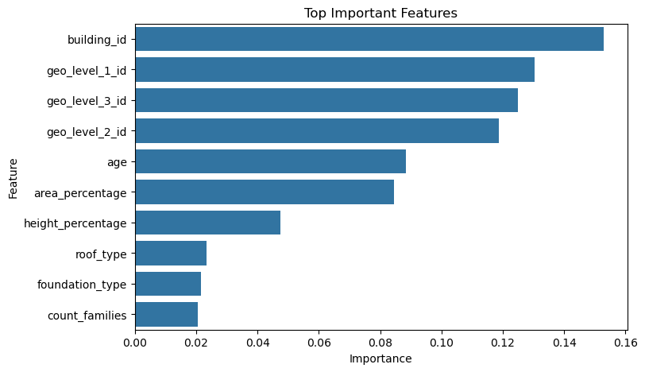

```python
top_features = importance.head(10)
plt.figure(figsize=(8,5))
sns.barplot(x='Importance',
            y='Feature',
            data=top_features)
plt.title("Top Important Features")
plt.show()
```

**TASK 3: STRATEGIC RECOMMENDATIONS FOR SEISMOLOGISTS & ENGINEERS**

To minimize building damage from future seismic events, structural policies must focus on engineering interventions rather than trying to predict exact earthquake timing:

**Retrofit High-Risk Superstructures:** Ban or heavily reinforce mud-mortar and stone compositions (has_superstructure_mud_mortar_stone) in high-risk zones. Introduce steel mesh wrapping or bamboo reinforcement grid layers.

**Mandatory Engineering Approvals:** Convert non-engineered reinforced concrete practices (has_superstructure_rc_non_engineered) into strict, code-compliant engineered structural configurations via localized building enforcement.

**Micro-Zoning Enforcement:** Use the goelogical findings (geo_level columns) to establish strict height limits (height_percentage) and floor limits (count_floors_pre_eq) in high-amplification soil zones.

**Foundation Upgrades:** Incentivize transitioning from isolated or rubble foundations to continuous or raft foundations (foundation_type), which distribute lateral seismic loads uniformly.

**REPORT ON CHALLENGES FACED & MITIGATION TECHNIQUES**

**1. High-Cardinality Categorical Variables**

**Challenge:** The featured geo_level_1_id, geo_level_2_id, and geo_level_3_id contain thousands of distinct spatial categories. One-hot encoding creates a massive matrix that crashes standard system memory.

**2. Extreme Outliers in Age Data**

**Challenge:** The age column contained placeholder values of 995 years. This artificially distorted the mathematical variance and skewed linear model convergence.

**3. Structural Class Imbalance**

**Challenge:** Grade 1 (low damage) represented only 10% of the dataset, leading baseline models to prioritize Grade 2 accuracy while ignoring severe risk categories.